# Sample Analysis of Station S08HA011 - Upper Cowichan Valley

Carl James Schwarz

2017-02-22

This will demonstrate a sample analysis of the stream discharge data from station 08HA011 (Upper Cowichan Valley) which is provided as a sample dataset (S08HA011) with this package. The basin has an area of 826 km**2. While the data fram runs from 1900 onwards, data was only reliably collected starting in 1965 onwards.

## Loading the data and some initial plots

We first load the package, load the data and look at the first few rows starting in 1965.

```r
library(ggplot2)
library(plyr)       # split-apply-combine paradigm
library(reshape2)   # for melting and casting

library(BCWaterDischargeAnalysis)


data(S08HA011)
head( S08HA011[ as.numeric(format(S08HA011$Date, "%Y"))==1965,])
```

```
##             Date    Q
## 23742 1965-01-01 46.4
## 23743 1965-01-02 45.0
## 23744 1965-01-03 44.5
## 23745 1965-01-04 39.6
## 23746 1965-01-05 38.2
## 23747 1965-01-06 36.5
```

**Notice that the flow dataframe MUST have two variables: Date, the day in standard R format, and Q - the daily discharge value.**

Missing values can be entered in two ways. First, the date with the missing value of Q can be dropped from the data frame. Second, the value of Q can be set to missing (NA). Both methods can be used together. An example of the impact of missing values occurs in the second half of this vignette.

We now set the variables limiting the years for which the analysis should be done and setting up other needed variables for the analysis.

```r
Station.Code <- '08HA011'
Station.Name <- 'Upper Cowichan River'
Station.Area <- 826    # square km's

start.year   <- 1965  # when do you want the analysis to start at.
end.year     <- 2012  # what is last year with complete data
```

## Preliminary screening

Before analyzing the discharge values, you should do some preliminary screening to check for unusual data values, count missing values etc.

Here are some suggestions:

```r
cat("Number of illegal date values ", sum(is.na(S08HA011$Date)), "\n")
```

```
## Number of illegal date values  0
```

```r
S08HA011[ is.na(S08HA011$Date),]     # sorry Microsoft, but feb 29 1900 is NOT a leap year
```

```
## [1] Date Q
## <0 rows> (or 0-length row.names)
```

```r
dim(S08HA011)  # size before removing illegal dates
```

```
## [1] 42734     2
```

```r
S08HA011 <- S08HA011[ !is.na(S08HA011$Date),]
dim(S08HA011)  # size after removing illegal dates
```

```
## [1] 42734     2
```

```r
# get a simple summary of the data
S08HA011$Year <- as.numeric(format(S08HA011$Date, "%Y")) # add the year to the data frame
# Table of simple statistics by year to help check for outliers, etc
S08HA011.sum <- plyr::ddply(S08HA011[ S08HA011$Year >= start.year & S08HA011$Year <=end.year,], "Year", plyr::summarize,
         n.days   = length(Year),
         n.Q      = sum (!is.na(Q)),
         n.miss.Q = sum ( is.na(Q)),
         min.Q    = min (Q, na.rm=TRUE),
         max.Q    = max (Q, na.rm=TRUE),
         mean.Q   = mean(Q,na.rm=TRUE),
         sd.Q     = sd  (Q,na.rm=TRUE))
S08HA011.sum
```

```
##    Year n.days n.Q n.miss.Q min.Q max.Q   mean.Q     sd.Q
## 1  1965    365 365        0  3.54 196.0 47.72625 44.55059
## 2  1966    365 365        0  5.80 362.0 60.32545 65.58664
## 3  1967    365 365        0  4.11 213.0 61.70992 53.65439
## 4  1968    366 366        0  5.10 450.0 69.52503 71.15098
## 5  1969    365 365        0  4.98 150.0 47.50655 35.52722
## 6  1970    365 365        0  4.25 153.0 36.84767 34.33385
## 7  1971    365 365        0  6.00 187.0 55.62266 39.62329
## 8  1972    366 366        0  5.83 425.0 53.93230 59.41003
## 9  1973    365 365        0  3.11 337.0 53.33545 64.81365
## 10 1974    365 365        0  3.28 343.0 69.46066 64.42318
## 11 1975    365 365        0  6.43 345.0 66.59186 65.38940
## 12 1976    366 366        0  4.62 165.0 47.77153 37.67202
## 13 1977    365 365        0  4.16 233.0 47.69573 47.43126
## 14 1978    365 365        0  4.64 101.0 30.25252 21.66569
```

[output cut: 34 more lines]

We see that there are no missing values in any of the year between the start and end year. This report is also generated later.

Let’s visuallize some of the statistics overtime

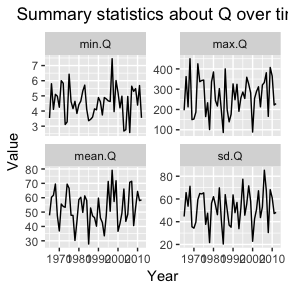

```r
# visuallize the min, max, and mean
plotdata <- reshape2::melt(S08HA011.sum,
             id.var='Year',
             measure.var=c("min.Q","max.Q","mean.Q","sd.Q"),
             variable.name='Statistic',
             value.name='Value')
ggplot2::ggplot(data=plotdata, aes(x=Year, y=Value))+
  ggtitle("Summary statistics about Q over time")+
  theme(plot.title = element_text(hjust = 0.5))+
  geom_line()+
  facet_wrap(~Statistic, ncol=2, scales="free_y")
```

## Computing the Annual Statistics (on calendar and water year)

We compute the plethora of annual statistics

```r
stat.annual <- compute.Q.stat.annual(
                          Station.Code  =Station.Code,
                          Station.Area  =Station.Area,
                          flow          =S08HA011,
                          start.year    =start.year,
                          end.year      =end.year)
```

This will create a list object with many elements:

```r
names(stat.annual)
```

```
##  [1] "Q.flow.summary"      "Q.stat.annual"       "Q.stat.annual.trans"
##  [4] "dates.missing.flows" "file.stat.csv"       "file.stat.trans.csv"
##  [7] "file.stat.trend.pdf" "file.cumdepart.pdf"  "file.summary.csv"
## [10] "file.lowflow.csv"    "na.rm"               "Version"
## [13] "Date"
```

This has many, many statistics some of which are shown below:

```r
head(stat.annual$Q.stat.annual[, 1:10])
```

```
##   Year CY_MIN_01Day_SW CY_MINDOY_01Day_SW CY_MIN_03Day_SW
## 1 1965            3.54                276              NA
## 2 1966            5.80                215        5.936667
## 3 1967            4.11                243        4.110000
## 4 1968            5.10                219        5.223333
## 5 1969            4.98                228        4.980000
## 6 1970            4.25                203        4.343333
##   CY_MINDOY_03Day_SW CY_MIN_07Day_SW CY_MINDOY_07Day_SW CY_MIN_30Day_SW
## 1                 NA              NA                 NA              NA
## 2                224        6.305714                225        6.445667
## 3                256        4.320000                269        4.652333
## 4                220        5.258571                223        6.569000
## 5                238        5.071429                240        5.357667
## 6                204        4.642857                206        5.035667
##   CY_MINDOY_30Day_SW CY_MIN_DAILY_SW
## 1                 NA            3.54
## 2                244            5.80
## 3                270            4.11
## 4                237            5.10
## 5                256            4.98
## 6                230            4.25
```

Notice the defaut acton (see below) is to propogate missing values. Despite a complete data record starting in 1965, there was no data available for 1964-12-31 which implies that a three-day rolling average that includes 1964-12-31 cannot be computed which gives a missing values for the 3-day rolling average minimum flow for 1965. This also occurs for other rolling averages that include any 1964 data such as water year computation for the 1965 water year which started on 1964-10-01.

These statistics can be then processed as you desire.

As well, the default arguments will also create several *.csv file with the summary statistics and a* .pdf file with the trends plotted over time in the directory you run the code in. The file names are given in the list object:

```r
stat.annual$file.stat.csv
```

```
## [1] "./08HA011-annual-summary-stat.csv"
```

```r
stat.annual$file.stat.trans.csv
```

```
## [1] "./08HA011-annual-summary-stat-trans.csv"
```

```r
stat.annual$file.stat.trend.pdf
```

```
## [1] "./08HA011-annual-trend.pdf"
```

## Computing the long term summary statistics

We compute the long term summary statistics

```r
stat.longterm <- compute.Q.stat.longterm(
                          Station.Code =Station.Code,
                          Station.Area =Station.Area,
                          flow         =S08HA011,
                          start.year   =start.year,
                          end.year     =end.year)
```

This will create a list object with many elements:

```r
names(stat.longterm)
```

```
## [1] "Q.stat.longterm"       "Q.stat.longterm.trans" "file.stat.csv"
## [4] "file.stat.trans.csv"   "na.rm"                 "Version"
## [7] "Date"
```

This has the long term summary statistics (mean, min, max, etc) by month some of which are shown below:

```r
head(stat.longterm$Q.stat.longterm)
```

```
##   Month      mean median   max   min
## 1     1 110.46828  98.65 450.0 15.60
## 2     2  92.69174  82.90 303.0 14.70
## 3     3  77.38508  68.85 359.0 15.80
## 4     4  57.23731  52.40 154.0  8.67
## 5     5  35.27665  31.00 121.0  6.47
## 6     6  18.18226  13.60  73.4  2.99
```

Because these statistics are computed on the calendar year basis and there were no missing values in the period of record, there are no missing summary statistics (see below for more details). These statistics can be then processed as you desire.

As well, the default arguments will also create several *.csv file with the summary statistics and a* .pdf file with the trends plotted over time in the directory you run the code in. The file names are given in the list object:

```r
stat.longterm$file.stat.csv
```

```
## [1] "./08HA011-longterm-summary-stat.csv"
```

```r
stat.longterm$file.stat.trans.csv
```

```
## [1] "./08HA011-longterm-summary-stat-trans.csv"
```

## Computing the long term percentile statistics

We compute the long term percentile statistics

```r
percentile.longterm <- compute.Q.percentile.longterm(
                          Station.Code=Station.Code,
                          Station.Area=Station.Area,
                          flow        =S08HA011,
                          start.year  =start.year,
                          end.year    =end.year)
```

This will create a list object with many elements:

```r
names(percentile.longterm)
```

```
## [1] "Q.percentile.stat"       "Q.percentile.stat.trans"
## [3] "file.stat.csv"           "file.stat.trans.csv"
## [5] "na.rm"                   "Version"
## [7] "Date"
```

This has the long term summary statistics (mean, min, max, etc) by month some of which are shown below:

```r
head(percentile.longterm$Q.percentile.stat)
```

```
##   Month     P01     P02    P05   P10   P15    P20    P25   P30     P35
## 1   Jan 21.8740 25.2000 31.480 40.41 49.60 58.600 65.800 70.81 78.2000
## 2   Feb 23.2550 29.7200 36.950 43.90 49.60 54.900 60.000 64.10 68.5250
## 3   Mar 20.3960 24.5740 29.235 36.07 41.91 47.200 51.300 55.40 58.9450
## 4   Apr 13.4000 16.0120 23.490 28.48 32.30 35.800 38.575 41.30 43.6000
## 5   May  7.4122  8.7748  9.867 12.20 14.20 16.100 18.350 21.31 23.7000
## 6   Jun  3.9500  4.6200  5.580  6.28  6.55  6.948  7.580  8.16  9.0965
##     P40    P45   P50     P55    P60     P65    P70     P75    P80     P85
## 1 84.94 92.215 98.65 106.000 112.00 120.550 129.00 141.000 152.60 169.900
## 2 73.10 77.275 82.90  89.150  95.40 101.000 107.00 114.000 122.00 133.000
## 3 62.60 65.115 68.85  71.385  74.84  79.000  85.40  92.900 101.00 112.950
## 4 45.66 48.655 52.40  56.000  59.70  63.700  68.00  72.425  77.34  85.000
## 5 26.40 29.000 31.00  33.400  36.62  40.055  43.70  49.000  54.30  60.295
## 6 10.70 12.000 13.60  15.200  16.84  18.800  20.63  23.025  26.82  32.215
##      P90     P95    P98     P99
## 1 194.00 239.650 282.26 321.000
## 2 154.00 186.000 229.80 245.450
## 3 132.30 161.650 188.26 209.520
## 4  93.91 107.000 120.00 131.610
## 5  65.83  72.800  79.13  84.082
## 6  40.40  49.005  57.20  63.954
```

Because these statistics are computed on the calendar year basis and there were no missing values in the period of record, there are no missing summary statistics (see below for more details).

These statistics can be then processed as you desire.

As well, the default arguments will also create several *.csv file with the summary statistics and a* .pdf file with the trends plotted over time in the directory you run the code in. The file names are given in the list object:

```r
percentile.longterm$file.stat.csv
```

```
## [1] "./08HA011-longterm-percentile-stat.csv"
```

```r
percentile.longterm$file.stat.trans.csv
```

```
## [1] "./08HA011-longterm-percentile-stat-trans.csv"
```

## Computing a volume frequency analysis

We compute the volume frequency analysis

```r
vfa.analysis <- compute.volume.frequency.analysis(
                      Station.Code   =Station.Code, S08HA011,
                      start.year     =start.year,
                      end.year       =end.year)
```

Because these statistics are computed on the calendar year basis and there were no missing values in the period of record, there was no impact of missingness on the computations.

This will create a list object with many elements:

```r
names(vfa.analysis)
```

```
##  [1] "start.year"              "end.year"
##  [3] "use.water.year"          "use.max"
##  [5] "roll.avg.days"           "Q.stat"
##  [7] "Q.stat.trans"            "plotdata"
##  [9] "prob.plot.position"      "freqplot"
## [11] "fit.distr"               "fit"
## [13] "fitted.quantiles"        "fitted.quantiles.trans"
## [15] "file.stat.csv"           "file.stat.trans.csv"
## [17] "file.plotdata.csv"       "file.quantile.csv"
## [19] "file.quantile.trans.csv" "file.frequency.plot"
## [21] "Version"                 "Date"
```

A frequencey plot is created as an object in the list, and also written to the directory

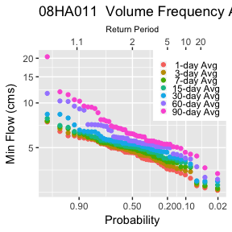

```r
vfa.analysis$freqplot
```

The quantiles from the fitted distribution (the default is a Pearson Log III distribution) are also computed:

```r
vfa.analysis$fitted.quantiles.trans
```

```
##    distr  prob     Return Q001-avg Q003-avg Q007-avg Q015-avg Q030-avg
## 1   PIII 0.010 100.000000 2.437537 2.544397 2.611767 2.738193 2.880917
## 2   PIII 0.050  20.000000 2.976171 3.108230 3.228087 3.378068 3.513155
## 3   PIII 0.100  10.000000 3.289789 3.433166 3.579166 3.739922 3.878317
## 4   PIII 0.200   5.000000 3.692997 3.846881 4.020310 4.191558 4.344346
## 5   PIII 0.500   2.000000 4.529539 4.689240 4.893066 5.073719 5.297933
## 6   PIII 0.800   1.250000 5.436928 5.575970 5.766214 5.938405 6.310295
## 7   PIII 0.900   1.111111 5.932125 6.046993 6.207631 6.367395 6.852380
## 8   PIII 0.950   1.052632 6.348495 6.435532 6.558702 6.704024 7.302151
## 9   PIII 0.975   1.025641 6.713263 6.770038 6.850824 6.980675 7.691466
## 10  PIII 0.980   1.020408 6.822247 6.868883 6.935265 7.060010 7.806904
## 11  PIII 0.990   1.010101 7.139578 7.153741 7.173624 7.282293 8.140661
##     Q060-avg  Q090-avg
## 1   3.263051  3.897470
## 2   3.783335  4.268720
## 3   4.116313  4.544873
## 4   4.582942  4.976665
## 5   5.721311  6.225931
## 6   7.303262  8.382377
## 7   8.373320 10.107665
## 8   9.419517 12.002292
## 9  10.469621 14.113078
## 10 10.811199 14.845393
## 11 11.888817 17.304941
```

These statistics can be then processed as you desire.

As well, the default arguments will also create several *.csv file with the summary statistics and a* .pdf file with the trends plotted over time in the directory you run the code in. The file names are given in the list object:

```r
vfa.analysis$file.stat.csv
```

```
## [1] "./08HA011-annual-vfa-stat.csv"
```

```r
vfa.analysis$file.quantile.csv
```

```
## [1] "./08HA011-annual-vfa-quantiles.csv"
```

```r
vfa.analysis$file.frequency.plot
```

```
## [1] "./08HA011-annual-vfa-frequency-plot.pdf"
```

# Missing Values

Accoding to the WSC,

> Monthly or annual values are not calculated unless there is complete daily record. If the gauge went down and the daily record cannot be reasonable estimated, then summaries at longer time scales (monthly, annual) are not computed.

This is controlled in all of function using the **na.rm** argument (similar to many R functions such as mean etc), but usage is slightly different from the standard R usage to allow future versions of the software to have finer control on dealing with missing values.

The treatment of missing values for all function is controlled through the **na.rm=list(na.rm.global=XXXXX)** argument. The current default actions are:

| Function | Default Action |
| --- | --- |
| compute.Q.stat.annual | na.rm=list(na.rm.global=FALSE) |
| compute.Q.stat.longterm | na.rm=list(na.rm.global=TRUE) |
| compute.Q.percentile.longterm | na.rm=list(na.rm.global=TRUE) |
| compute.volume.frequency.analysis | na.rm=list(na.rm.global=TRUE) |

If **na.rm=list(na.rm.global=FALSE)**, i.e. do NOT remove missing values before computing statistics, then if there is a missing value present in a series, the missingness is propagated forward. For example, if a month is missing a value, then the minimum flow for that month in that year is not computed, but the minimum flows in the other months are computed. The minimum flow for that year that has the missing value is also not computed. If the missing value was in January, then the JFM season missing is also not computed, but the minimum for AMJ etc are computed. Similarly for the 6 month averages if they have a complete record. The rule is the same for both the CY (calendar year) and WY (water year) statistics.

The missing value also affect an rolling average that includes the missing value. This may cross month boundaries, e.g. if the missing value occurred on 31 January, then the 3 day rolling average for the 1 Feb is also missing so the Feb statistics on the 3 day rolling average are also not computed. If the missing value occurred at the end of a year, the rolling average in january of the next year may be affected, and so on.

There is also an unintended consequence with the rolling averages. In the first year of the series, the 3, 7, and 30 day rolling averages for the 1st january will be missing and so any monthly/ season/ yearly statistic on the rolling averages will also be missing. The way around this is to INCLUDE data prior to 1 January, e.g. the actual data record runs from 1940 onwards, but you set the **start.year=1941**. Then the rolling average for 1941-01-01 can be computed etc.

Because the first year water year starts in the previous October, many off the water year statistics will be missing for the first year, unless you again include more data before the start.year (as above).

If **na.rm=list(na.rm.glob=TRUE)**, then ALL statistics are computed with the missing value excluded, i.e. in a month with a missing value, the statistic is computed on the remaining values.

For example, the default action to deal missing values for the long-term statistics is to EXCLUDE all missing values, and so statistics are still computed. For example, if 1942-05-12 has a missing value, any statistics about May will ignore this missing value and at the long-term averages will still be computed,

There is a bit of weirdness if you choose to analyze on the water year and set the **na.rm.global=TRUE**, because it will compute statistics for the first water year even though you may be missing data from the previous Cctober. Be careful.

## Example of analysis with missing values.

We will take the previous dataset that is complete and create a few missing values.

```r
data(S08HA011)
head( S08HA011[ as.numeric(format(S08HA011$Date, "%Y"))==1965,])
```

```
##             Date    Q
## 23742 1965-01-01 46.4
## 23743 1965-01-02 45.0
## 23744 1965-01-03 44.5
## 23745 1965-01-04 39.6
## 23746 1965-01-05 38.2
## 23747 1965-01-06 36.5
```

**Notice that the flow dataframw MUST have two variables: Date, the day in standard R format, and Q - the daily discharge value.**

We now set the variables limiting the years for which the analysis should be done and setting up needed variables.

```r
Station.Code <- '08HA011'
Station.Name <- 'Upper Cowichan River'
Station.Area <- 826    # square km's

start.year   <- 1965  # when do you want the analysis to start at.
end.year     <- 2012  # what is last year with complete data

# add Year to the data frame
S08HA011$Year <- as.numeric(format(S08HA011$Date, "%Y")) # add the year to the data frame
```

We now create some missing values.

```r
# Create 1% missing values (approximately)
set.seed(3423432)
sum(is.na(S08HA011[ start.year <= S08HA011$Year & S08HA011$Year <= end.year, "Q"]))
```

```
## [1] 0
```

```r
missing <- sample(1:nrow(S08HA011), .0003*nrow(S08HA011))
S08HA011$Q[ missing ] <- NA
sum(is.na(S08HA011[ start.year <= S08HA011$Year & S08HA011$Year <= end.year, "Q"]))
```

```
## [1] 4
```

The simple summary statistics are computed as before.

```r
# get a simple summary of the data
# Table of simple statistics by year to help check for outliers, etc
S08HA011.sum <- plyr::ddply(S08HA011[ S08HA011$Year >= start.year & S08HA011$Year <=end.year,], "Year", plyr::summarize,
         n.days   = length(Year),
         n.Q      = sum (!is.na(Q)),
         n.miss.Q = sum ( is.na(Q)),
         min.Q    = min (Q, na.rm=TRUE),
         max.Q    = max (Q, na.rm=TRUE),
         mean.Q   = mean(Q,na.rm=TRUE),
         sd.Q     = sd  (Q,na.rm=TRUE))
S08HA011.sum
```

```
##    Year n.days n.Q n.miss.Q min.Q max.Q   mean.Q     sd.Q
## 1  1965    365 365        0  3.54 196.0 47.72625 44.55059
## 2  1966    365 365        0  5.80 362.0 60.32545 65.58664
## 3  1967    365 364        1  4.11 213.0 61.78137 53.71085
## 4  1968    366 366        0  5.10 450.0 69.52503 71.15098
## 5  1969    365 365        0  4.98 150.0 47.50655 35.52722
## 6  1970    365 365        0  4.25 153.0 36.84767 34.33385
## 7  1971    365 365        0  6.00 187.0 55.62266 39.62329
## 8  1972    366 366        0  5.83 425.0 53.93230 59.41003
## 9  1973    365 365        0  3.11 337.0 53.33545 64.81365
## 10 1974    365 365        0  3.28 343.0 69.46066 64.42318
## 11 1975    365 365        0  6.43 345.0 66.59186 65.38940
## 12 1976    366 366        0  4.62 165.0 47.77153 37.67202
## 13 1977    365 365        0  4.16 233.0 47.69573 47.43126
## 14 1978    365 365        0  4.64 101.0 30.25252 21.66569
```

[output cut: 34 more lines]

We see that there are now missing values in a few years (e.g. 1967).

## Computing the Annual Statistics (on calendar and water year)

We compute the plethora of annual statistics with the default action to propogate missing values.

```r
stat.annual <- compute.Q.stat.annual(
                          Station.Code  =Station.Code,
                          Station.Area  =Station.Area,
                          flow          =S08HA011,
                          start.year    =start.year,
                          end.year      =end.year)
```

This has many, many statistics some of which are shown below. Notice that some are now missing (e.g. in 1967) over and above the missing in the rolling averages for the first year.

```r
head(stat.annual$Q.stat.annual[, 1:10])
```

```
##   Year CY_MIN_01Day_SW CY_MINDOY_01Day_SW CY_MIN_03Day_SW
## 1 1965            3.54                276              NA
## 2 1966            5.80                215        5.936667
## 3 1967              NA                 NA              NA
## 4 1968            5.10                219        5.223333
## 5 1969            4.98                228        4.980000
## 6 1970            4.25                203        4.343333
##   CY_MINDOY_03Day_SW CY_MIN_07Day_SW CY_MINDOY_07Day_SW CY_MIN_30Day_SW
## 1                 NA              NA                 NA              NA
## 2                224        6.305714                225        6.445667
## 3                 NA              NA                 NA              NA
## 4                220        5.258571                223        6.569000
## 5                238        5.071429                240        5.357667
## 6                204        4.642857                206        5.035667
##   CY_MINDOY_30Day_SW CY_MIN_DAILY_SW
## 1                 NA            3.54
## 2                244            5.80
## 3                 NA              NA
## 4                237            5.10
## 5                256            4.98
## 6                230            4.25
```

To ignore the missing values, we set the parameter:

```r
stat.annual.ignore.missing <- compute.Q.stat.annual(
                          Station.Code  =Station.Code,
                          Station.Area  =Station.Area,
                          flow          =S08HA011,
                          start.year    =start.year,
                          end.year      =end.year,
                          na.rm=list(na.rm.global=TRUE))
head(stat.annual.ignore.missing$Q.stat.annual[, 1:10])
```

```
##   Year CY_MIN_01Day_SW CY_MINDOY_01Day_SW CY_MIN_03Day_SW
## 1 1965            3.54                276        3.746667
## 2 1966            5.80                215        5.936667
## 3 1967            4.11                243        4.110000
## 4 1968            5.10                219        5.223333
## 5 1969            4.98                228        4.980000
## 6 1970            4.25                203        4.343333
##   CY_MINDOY_03Day_SW CY_MIN_07Day_SW CY_MINDOY_07Day_SW CY_MIN_30Day_SW
## 1                276        4.224286                276        5.070000
## 2                224        6.305714                225        6.445667
## 3                256        4.320000                269        4.652333
## 4                220        5.258571                223        6.569000
## 5                238        5.071429                240        5.357667
## 6                204        4.642857                206        5.035667
##   CY_MINDOY_30Day_SW CY_MIN_DAILY_SW
## 1                223            3.54
## 2                244            5.80
## 3                270            4.11
## 4                237            5.10
## 5                256            4.98
## 6                230            4.25
```

Notice that all statistics are computed even if there were missing values.

## Computing the long term summary statistics

The long-term summary statistics default action is to IGNORE the missing values.

```r
stat.longterm <- compute.Q.stat.longterm(
                          Station.Code =Station.Code,
                          Station.Area =Station.Area,
                          flow         =S08HA011,
                          start.year   =start.year,
                          end.year     =end.year)
head(stat.longterm$Q.stat.longterm)
```

```
##   Month      mean median   max   min
## 1     1 110.46828  98.65 450.0 15.60
## 2     2  92.69174  82.90 303.0 14.70
## 3     3  77.37176  68.80 359.0 15.80
## 4     4  57.23731  52.40 154.0  8.67
## 5     5  35.27636  31.00 121.0  6.47
## 6     6  18.18267  13.60  73.4  2.99
```

If you wish missing values to propogate, use:

```r
stat.longterm.missing <- compute.Q.stat.longterm(
                          Station.Code =Station.Code,
                          Station.Area =Station.Area,
                          flow         =S08HA011,
                          start.year   =start.year,
                          end.year     =end.year,
                          na.rm=list(na.rm.global=FALSE))
head(stat.longterm.missing$Q.stat.longterm)
```

```
##   Month      mean median max   min
## 1     1 110.46828  98.65 450 15.60
## 2     2  92.69174  82.90 303 14.70
## 3     3        NA     NA  NA    NA
## 4     4  57.23731  52.40 154  8.67
## 5     5        NA     NA  NA    NA
## 6     6        NA     NA  NA    NA
```

## Computing the long term percentile statistics

The long-term percentile statistics default action is to IGNORE the missing values.

```r
percentile.longterm <- compute.Q.percentile.longterm(
                          Station.Code=Station.Code,
                          Station.Area=Station.Area,
                          flow        =S08HA011,
                          start.year  =start.year,
                          end.year    =end.year)
head(percentile.longterm$Q.percentile.stat)
```

```
##   Month     P01     P02    P05   P10   P15    P20    P25   P30    P35
## 1   Jan 21.8740 25.2000 31.480 40.41 49.60 58.600 65.800 70.81 78.200
## 2   Feb 23.2550 29.7200 36.950 43.90 49.60 54.900 60.000 64.10 68.525
## 3   Mar 20.3880 24.5720 29.230 36.06 41.89 47.200 51.300 55.38 58.910
## 4   Apr 13.4000 16.0120 23.490 28.48 32.30 35.800 38.575 41.30 43.600
## 5   May  7.4116  8.7744  9.866 12.20 14.20 16.100 18.300 21.30 23.700
## 6   Jun  3.9500  4.6200  5.580  6.28  6.55  6.946  7.580  8.16  9.093
##     P40    P45   P50    P55    P60    P65    P70     P75    P80    P85
## 1 84.94 92.215 98.65 106.00 112.00 120.55 129.00 141.000 152.60 169.90
## 2 73.10 77.275 82.90  89.15  95.40 101.00 107.00 114.000 122.00 133.00
## 3 62.60 65.100 68.80  71.33  74.80  79.00  85.40  92.850 101.00 113.10
## 4 45.66 48.655 52.40  56.00  59.70  63.70  68.00  72.425  77.34  85.00
## 5 26.40 28.940 31.00  33.40  36.66  40.09  43.70  49.000  54.30  60.30
## 6 10.70 12.000 13.60  15.19  16.80  18.80  20.66  23.050  26.84  32.23
##      P90    P95    P98     P99
## 1 194.00 239.65 282.26 321.000
## 2 154.00 186.00 229.80 245.450
## 3 132.40 161.70 188.28 209.560
## 4  93.91 107.00 120.00 131.610
## 5  65.84  72.80  79.14  84.096
## 6  40.40  49.01  57.20  63.968
```

If you want to propogate missing values, again set the **na.rm** argument:

```r
percentile.longterm.missing <- compute.Q.percentile.longterm(
                          Station.Code=Station.Code,
                          Station.Area=Station.Area,
                          flow        =S08HA011,
                          start.year  =start.year,
                          end.year    =end.year,
                          na.rm=list(na.rm.global=FALSE))
head(percentile.longterm.missing$Q.percentile.stat)
```

```
##   Month    P01    P02   P05   P10  P15  P20    P25   P30    P35   P40
## 1   Jan 21.874 25.200 31.48 40.41 49.6 58.6 65.800 70.81 78.200 84.94
## 2   Feb 23.255 29.720 36.95 43.90 49.6 54.9 60.000 64.10 68.525 73.10
## 3   Mar     NA     NA    NA    NA   NA   NA     NA    NA     NA    NA
## 4   Apr 13.400 16.012 23.49 28.48 32.3 35.8 38.575 41.30 43.600 45.66
## 5   May     NA     NA    NA    NA   NA   NA     NA    NA     NA    NA
## 6   Jun     NA     NA    NA    NA   NA   NA     NA    NA     NA    NA
##      P45   P50    P55   P60    P65 P70     P75    P80   P85    P90    P95
## 1 92.215 98.65 106.00 112.0 120.55 129 141.000 152.60 169.9 194.00 239.65
## 2 77.275 82.90  89.15  95.4 101.00 107 114.000 122.00 133.0 154.00 186.00
## 3     NA    NA     NA    NA     NA  NA      NA     NA    NA     NA     NA
## 4 48.655 52.40  56.00  59.7  63.70  68  72.425  77.34  85.0  93.91 107.00
## 5     NA    NA     NA    NA     NA  NA      NA     NA    NA     NA     NA
## 6     NA    NA     NA    NA     NA  NA      NA     NA    NA     NA     NA
##      P98    P99
## 1 282.26 321.00
## 2 229.80 245.45
## 3     NA     NA
## 4 120.00 131.61
## 5     NA     NA
## 6     NA     NA
```

## Computing a volume frequency analysis

The volume frequence analysis automatically drops missing values:

```r
vfa.analysis <- compute.volume.frequency.analysis(
                      Station.Code   =Station.Code, S08HA011,
                      start.year     =start.year,
                      end.year       =end.year)
vfa.analysis$fitted.quantiles.trans
```

```
##    distr  prob     Return Q001-avg Q003-avg Q007-avg Q015-avg Q030-avg
## 1   PIII 0.010 100.000000 2.437537 2.544397 2.611767 2.738193 2.880917
## 2   PIII 0.050  20.000000 2.976171 3.108230 3.228087 3.378068 3.513155
## 3   PIII 0.100  10.000000 3.289789 3.433166 3.579166 3.739922 3.878317
## 4   PIII 0.200   5.000000 3.692997 3.846881 4.020310 4.191558 4.344346
## 5   PIII 0.500   2.000000 4.529539 4.689240 4.893066 5.073719 5.297933
## 6   PIII 0.800   1.250000 5.436928 5.575970 5.766214 5.938405 6.310295
## 7   PIII 0.900   1.111111 5.932125 6.046993 6.207631 6.367395 6.852380
## 8   PIII 0.950   1.052632 6.348495 6.435532 6.558702 6.704024 7.302151
## 9   PIII 0.975   1.025641 6.713263 6.770038 6.850824 6.980675 7.691466
## 10  PIII 0.980   1.020408 6.822247 6.868883 6.935265 7.060010 7.806904
## 11  PIII 0.990   1.010101 7.139578 7.153741 7.173624 7.282293 8.140661
##     Q060-avg  Q090-avg
## 1   3.257945  3.820377
## 2   3.803850  4.244597
## 3   4.149801  4.552287
## 4   4.630680  5.025881
## 5   5.787290  6.368893
## 6   7.362566  8.642141
## 7   8.410619 10.438321
## 8   9.423576 12.394999
## 9  10.429875 14.559549
## 10 10.755119 15.307267
## 11 11.774964 17.807848
```

```r
vfa.analysis.missing <- compute.volume.frequency.analysis(
                      Station.Code   =Station.Code, S08HA011,
                      start.year     =start.year,
                      end.year       =end.year,
                      na.rm=list(na.rm.global=FALSE))
vfa.analysis.missing$fitted.quantiles.trans
```

```
##    distr  prob     Return Q001-avg Q003-avg Q007-avg Q015-avg Q030-avg
## 1   PIII 0.010 100.000000 2.392825 2.493076 2.542913 2.672973 2.805126
## 2   PIII 0.050  20.000000 2.968353 3.116283 3.214208 3.368355 3.485497
## 3   PIII 0.100  10.000000 3.302028 3.472312 3.595274 3.760092 3.877631
## 4   PIII 0.200   5.000000 3.728208 3.919953 4.070265 4.244979 4.375493
## 5   PIII 0.500   2.000000 4.597956 4.803839 4.988868 5.170371 5.379300
## 6   PIII 0.800   1.250000 5.512047 5.681369 5.865335 6.034586 6.413169
## 7   PIII 0.900   1.111111 5.995297 6.120604 6.286412 6.441483 6.949490
## 8   PIII 0.950   1.052632 6.392037 6.467046 6.608333 6.748043 7.383814
## 9   PIII 0.975   1.025641 6.731892 6.752941 6.866200 6.990266 7.751191
## 10  PIII 0.980   1.020408 6.831972 6.835125 6.938889 7.057939 7.858502
## 11  PIII 0.990   1.010101 7.119398 7.065875 7.139237 7.242910 8.164366
##     Q060-avg  Q090-avg
## 1   3.168508  3.784448
## 2   3.742962  4.212080
## 3   4.106501  4.521116
## 4   4.611158  4.995637
## 5   5.821678  6.336734
## 6   7.462880  8.598115
## 7   8.550120 10.380025
## 8   9.597543 12.317516
## 9  10.634900 14.457222
## 10 10.969525 15.195585
## 11 12.016773 17.662334
```

The years with the missing values will be DROPPED from the analysis, and the analysis will continue with the remaining years of data, i.e. the sample size for fitting the distributions will be reduced. It is difficult to see this in action other than by actually looking at the plotting data for the frequency plot and comparing to the same summary with no missing data.

```r
plyr::ddply(vfa.analysis.missing$plotdata, "Measure", plyr::summarize, n.years=length(Measure))
```

```
##    Measure n.years
## 1 Q001-avg      45
## 2 Q003-avg      44
## 3 Q007-avg      44
## 4 Q015-avg      44
## 5 Q030-avg      44
## 6 Q060-avg      44
## 7 Q090-avg      44
```

```r
plyr::ddply(vfa.analysis$plotdata        , "Measure", plyr::summarize, n.years=length(Measure))
```

```
##    Measure n.years
## 1 Q001-avg      48
## 2 Q003-avg      48
## 3 Q007-avg      48
## 4 Q015-avg      48
## 5 Q030-avg      48
## 6 Q060-avg      48
## 7 Q090-avg      48
```